# Exercise: Testing the model’s interoperability

I hope you like rollercosters

## Scenario

Image the same person from exercise 2 comes back with a new finding and a new request:

> I just found the SAS results dataset corresponding to the analysis you did before! It was stored in a no-so-ideally-named folder and, unfortunately, I could not find the corresponding script to recreate the analysis. Please, plot these results and compare to your previous KM plots to confirm the results match.

To ensure these results are not lost again and to test the robustness of our model, we will add the SAS results to our tables . Then, we can apply the same code from exercise 1 to recreate the Kaplan-Meier plot.

## Explore the data

First, let’s explore the analysis results datasets and determine if we can map it, as-is, to the data model. In this case, we were given a dataset with analysis results.

```r
sas_data <- read_sas(here("data", "survival_ard.sas7bdat"))

glimpse(sas_data)
```

```
Rows: 475
Columns: 8
$ TRTP       <chr> "medical", "medical", "medical", "medical", "medical", "med…
$ AVAL       <dbl> 0, 1, 2, 3, 4, 5, 6, 7, 8, 9, 10, 11, 12, 13, 14, 15, 18, 1…
$ `_CENSOR_` <dbl> NA, 0, 0, 0, 0, 0, 0, 0, 0, 0, 0, 0, 0, 0, 0, 0, 0, 0, 0, 0…
$ SURVIVAL   <dbl> 1.0000000, 0.9960159, 0.9920319, 0.9880478, 0.9800797, 0.97…
$ SDF_STDERR <dbl> 0.000000000, 0.003976119, 0.005611825, 0.006859238, 0.00881…
$ SDF_LCL    <dbl> 1.0000000, 0.9882533, 0.9810936, 0.9746950, 0.9629454, 0.95…
$ SDF_UCL    <dbl> 1.0000000, 1.0000000, 1.0000000, 1.0000000, 0.9975188, 0.99…
$ STRATUM    <dbl> 1, 1, 1, 1, 1, 1, 1, 1, 1, 1, 1, 1, 1, 1, 1, 1, 1, 1, 1, 1,…
```

Hmm, I’m not sure what these variables mean. Luckily, the SAS documentation is freely available. There also seems to be a mismatch in the column names (and case) although they refer to the same variable (i.e., TRTP and Stratum). We have to take some educated guesses.

[figure not shown]

Now, we can check our data model and verify if we have all the information needed to fill the `survival_ard` table.

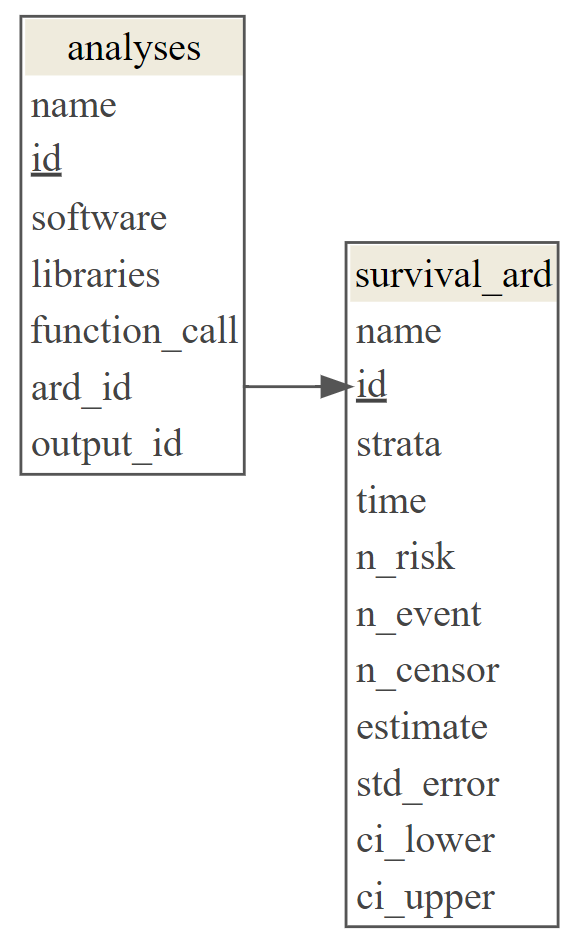

### Fill the `survival_ard` table

Unfortunately, this data sets does not contain information on the number at risk and number of event. However, we can fill the `survival_ard` table with the available information. Next, we can fill the `analyses_metadata` table.

```r
load(file = here("data", "survival_ard.rda"))

sas_ard <- sas_data |>
  mutate(name = "sas_survival_01",
         id = "ARD02") |>
  rename(
    strata = TRTP,
    time = AVAL,
    n_censor = `_CENSOR_`,
    estimate = SURVIVAL,
    std_error = SDF_STDERR,
    ci_lower = SDF_LCL,
    ci_upper = SDF_UCL
  )  |>
  mutate(n_risk = NA,
         n_event = NA) |>
  select(-STRATUM, names(survival_ard))


survival_ard <- rbind(survival_ard, sas_ard)
save(survival_ard, file = here("data", "survival_ard.rda"))
```

### Fill the `analyses_metadata` table

This one is more tricky since we do not have much information in the datasets provided. All we know is the name of the procedure and the software used. As output_id we will use the same as in exercise 1 and 2.

```r
load(file = here("data", "analyses_metadata.rda"))

sas_analyses <- tibble(
  name = "sas_survival_analysis_01",
  id = "A02",
  software = "SAS",
  software_version = NA,
  libraries = NA,
  function_call = "proc lifetest",
  ard_id = "ARD02",
  output_id = "OUT01"
)

analyses_metadata <- rbind(analyses_metadata, sas_analyses)
save(analyses_metadata, file = here("data", "analyses_metadata.rda"))
```

### Reproducing the plot

We can now reproduce the plot using the code from exercise 1 using the data in *survival_ard* and *outputs*.

```r
load(file = here("data", "analyses_metadata.rda"))
load(file = here("data", "survival_ard.rda"))
load(file = here("data", "outputs.rda"))

sas_analysis <- analyses_metadata |>
  filter(id == "A02")

sas_output <- outputs |>
  filter(id == sas_analysis$output_id)

sas_surv_ard <- survival_ard |>
  filter(id == sas_analysis$ard_id)
```

```r
title <- sas_output |>
  filter(type == "title")

xlab <- sas_output |>
  filter(type == "xlab")

ylab <- sas_output |>
  filter(type == "ylab")

legend <- sas_output |>
  filter(type == "legend")

legend_colors <- str_split(legend$color, pattern = ", ", simplify = T) |>
  str_split(pattern = " = ", simplify = T)
```

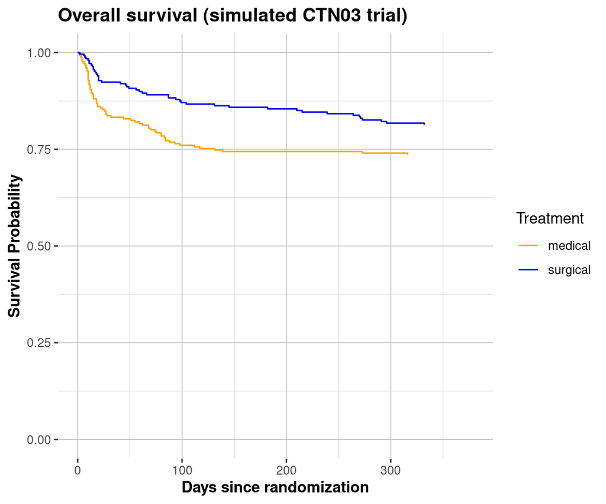

```r
plot_original <-
  sas_surv_ard |>
  ggplot(aes(x = time, y = estimate, ymin = ci_lower, ymax = ci_upper)) +
  geom_step(aes(colour = strata)) +
  theme(
    legend.position = legend$location,
    legend.key = element_rect(fill = "white"),
    panel.background = element_rect(fill = "white"),
    panel.grid.major = element_line(
      linewidth = 0.3, linetype = "solid",
      colour = "grey"
    ),
    panel.grid.minor = element_line(
      linewidth = 0.1, linetype = "solid",
      colour = "grey"
    ),
    plot.title = element_text(face = title$weight),
    axis.title.y = element_text(face = ylab$weight),
    axis.title.x = element_text(face = xlab$weight)
  ) +
  expand_limits(x = 0, y = 0) +
  ylab(ylab$text) +
  xlab(xlab$text) +
  ggtitle(title$text) +
  guides(color = guide_legend(title = legend$text)) +
  scale_color_manual(
    limits = legend_colors[, 1],
    values = legend_colors[, 2]
  )

plot_original
```

#### Comparing plots

When looking at both plots, it seems there are differences in the curves. For example, between days 0-50.

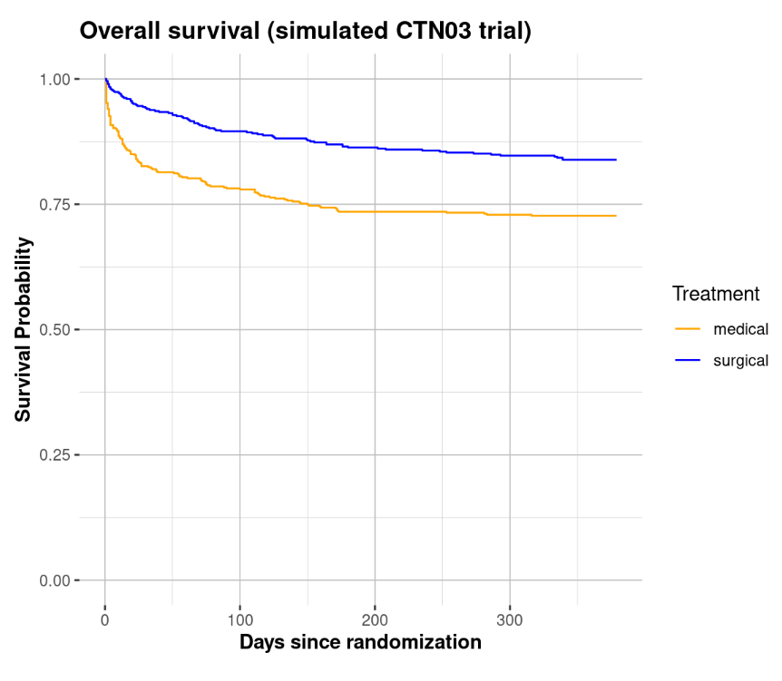

(a) Kaplan-Meier plot using A01 (R) results data.

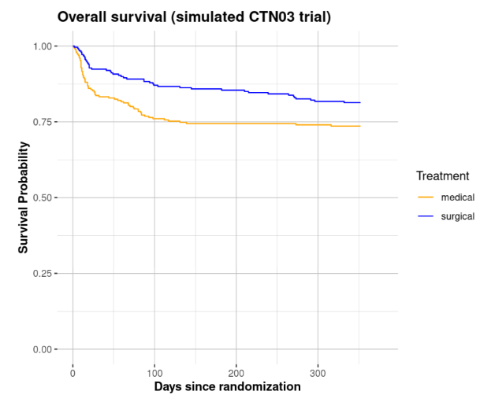

(b) Kaplan-Meier plot using A02 (SAS) results data.

Figure 1: Comparing the two plots.

Another look at the SAS documentation shows that the out-of-box procedure *lifetest* calculates the confidence bands using [*log-log*](https://documentation.sas.com/doc/en/pgmsascdc/9.4_3.4/statug/statug_lifetest_syntax01.htm#statug.lifetest.lftconftype). Instead, R’s {survival} `Surv()` uses *log transformation*. You can find more about discrepancies between software in the [CAMIS website](https://psiaims.github.io/CAMIS/).

Unfortunately, this is not clear from the data model. To spot this difference one would need to be familiar with both algorithms. Ideally, the data model would also capture this information. This means we need to redesign the `analyses_metadata` table.

## Back to the drawing board

The robustness of a data model is the key to its adoption. Constructing a rigid structure is difficult but, if we think about the data model as modular we can add new tables to store information that can not fit in the existing structure. For example, by creating a new linked table with additional information that only applies to certain analyses.

Take a few minutes to think and discuss about this problem:

- What other information do you think it is relevant to keep about an analysis?
- What if you wanted to store results from other modalities such as genome-wide association studies (GWAS)?

## Additional (take-home) tasks and questions

1. You were just given another SAS dataset complementing the previous one (*survival_ard_part2.sas7bdat* in /data). This new dataset also includes the number at risk and number of events information. How would edit the *survival_ard* analysis A02 to add this information?
2. Try to do the same exercise using a survival analysis output from another language you are familiar with. Are we missing important information?